# Week 3 in-class activity RMarkdown

Meagan Docherty

2024-01-24

First, set up by loading the data and any required libraries:

```r
# I am setting message=F and warning=F to turn off messages and warnings that R prints when it loads the libraries.
# first I'll load in the data:
load("C:/Users/mdocher/OneDrive - Bowling Green State University 2/Classes/PSYC 7800/Spring 2020/Data/Pathways/pathways data wide.Rda")
#load("C:/Users/doche/OneDrive - Bowling Green State University/Classes/PSYC 7800/Spring 2020/Data/Pathways/pathways data wide.Rda")
# then I'll load any required libraries:
library(lavaan)
library(psych)
library(ggplot2)
```

1. Model an intercept-only growth curve for self-regulation (walden) from baseline to the seven-year follow-up using all 11 time points. Obtain parameter estimates and model fit indices.

```r
intMod <- "I =~ 1*walden_0 + 1*walden_1 + 1*walden_2 + 1*walden_3 + 1*walden_4 + 1*walden_5 + 1*walden_6 + 1*walden_7 + 1*walden_8 + 1*walden_9 + 1*walden_10"
intFit <- growth(intMod, data=pathwayswide)
summary(intFit, fit.measures=T)
```

```
## lavaan 0.6.15 ended normally after 30 iterations
##
##   Estimator                                         ML
##   Optimization method                           NLMINB
##   Number of model parameters                        13
##
##                                                   Used       Total
##   Number of observations                           859        1354
##
## Model Test User Model:
##
##   Test statistic                               460.162
##   Degrees of freedom                                64
##   P-value (Chi-square)                           0.000
##
## Model Test Baseline Model:
##
##   Test statistic                              3602.650
##   Degrees of freedom                                55
##   P-value                                        0.000
##
## User Model versus Baseline Model:
##
##   Comparative Fit Index (CFI)                    0.888
##   Tucker-Lewis Index (TLI)                       0.904
##
## Loglikelihood and Information Criteria:
##
##   Loglikelihood user model (H0)              -8123.831
##   Loglikelihood unrestricted model (H1)      -7893.750
##
##   Akaike (AIC)                               16273.663
##   Bayesian (BIC)                             16335.488
##   Sample-size adjusted Bayesian (SABIC)      16294.203
##
## Root Mean Square Error of Approximation:
##
##   RMSEA                                          0.085
##   90 Percent confidence interval - lower         0.078
##   90 Percent confidence interval - upper         0.092
```

[output cut: 42 more lines]

```
##
## Variances:
##                    Estimate  Std.Err  z-value  P(>|z|)
##    .walden_0          0.313    0.016   19.296    0.000
##    .walden_1          0.317    0.016   19.316    0.000
##    .walden_2          0.267    0.014   19.052    0.000
##    .walden_3          0.226    0.012   18.746    0.000
##    .walden_4          0.231    0.012   18.785    0.000
##    .walden_5          0.245    0.013   18.898    0.000
##    .walden_6          0.240    0.013   18.860    0.000
##    .walden_7          0.267    0.014   19.048    0.000
##    .walden_8          0.281    0.015   19.134    0.000
##    .walden_9          0.280    0.015   19.130    0.000
##    .walden_10         0.298    0.016   19.227    0.000
##     I                 0.192    0.010   18.393    0.000
```

2. Model a linear growth curve for self-regulation (walden) from baseline to the seven-year follow-up using all 11 time points. Obtain parameter estimates and model fit indices.

```r
linMod <- "I =~ 1*walden_0 + 1*walden_1 + 1*walden_2 + 1*walden_3 + 1*walden_4 + 1*walden_5 + 1*walden_6 + 1*walden_7 + 1*walden_8 + 1*walden_9 + 1*walden_10
L =~ 0*walden_0 + 1*walden_1 + 2*walden_2 + 3*walden_3 + 4*walden_4 + 5*walden_5 + 6*walden_6 + 8*walden_7 + 10*walden_8 + 12*walden_9 + 14*walden_10"
linFit <- growth(linMod, data=pathwayswide)
summary(linFit, fit.measures=T)
```

```
## lavaan 0.6.15 ended normally after 57 iterations
##
##   Estimator                                         ML
##   Optimization method                           NLMINB
##   Number of model parameters                        16
##
##                                                   Used       Total
##   Number of observations                           859        1354
##
## Model Test User Model:
##
##   Test statistic                               283.726
##   Degrees of freedom                                61
##   P-value (Chi-square)                           0.000
##
## Model Test Baseline Model:
##
##   Test statistic                              3602.650
##   Degrees of freedom                                55
##   P-value                                        0.000
##
## User Model versus Baseline Model:
##
##   Comparative Fit Index (CFI)                    0.937
##   Tucker-Lewis Index (TLI)                       0.943
##
## Loglikelihood and Information Criteria:
##
##   Loglikelihood user model (H0)              -8035.613
##   Loglikelihood unrestricted model (H1)      -7893.750
##
##   Akaike (AIC)                               16103.227
##   Bayesian (BIC)                             16179.319
##   Sample-size adjusted Bayesian (SABIC)      16128.508
##
## Root Mean Square Error of Approximation:
##
##   RMSEA                                          0.065
##   90 Percent confidence interval - lower         0.058
##   90 Percent confidence interval - upper         0.073
```

[output cut: 61 more lines]

```
## Variances:
##                    Estimate  Std.Err  z-value  P(>|z|)
##    .walden_0          0.287    0.016   17.706    0.000
##    .walden_1          0.282    0.016   18.156    0.000
##    .walden_2          0.240    0.013   18.168    0.000
##    .walden_3          0.212    0.012   18.245    0.000
##    .walden_4          0.227    0.012   18.681    0.000
##    .walden_5          0.247    0.013   18.994    0.000
##    .walden_6          0.243    0.013   19.012    0.000
##    .walden_7          0.259    0.014   18.936    0.000
##    .walden_8          0.250    0.014   18.291    0.000
##    .walden_9          0.232    0.014   16.981    0.000
##    .walden_10         0.237    0.015   15.382    0.000
##     I                 0.230    0.014   16.089    0.000
##     L                 0.001    0.000    9.594    0.000
```

3. Model a quadratic growth curve for self-regulation (walden) from baseline to the seven-year follow-up using all 11 time points. Obtain parameter estimates and model fit indices.

```r
quaMod <- "I =~ 1*walden_0 + 1*walden_1 + 1*walden_2 + 1*walden_3 + 1*walden_4 + 1*walden_5 + 1*walden_6 + 1*walden_7 + 1*walden_8 + 1*walden_9 + 1*walden_10
L =~ 0*walden_0 + 1*walden_1 + 2*walden_2 + 3*walden_3 + 4*walden_4 + 5*walden_5 + 6*walden_6 + 8*walden_7 + 10*walden_8 + 12*walden_9 + 14*walden_10
Q =~ 0*walden_0 + 1*walden_1 + 4*walden_2 + 9*walden_3 + 16*walden_4 + 25*walden_5 + 36*walden_6 + 64*walden_7 + 100*walden_8 + 144*walden_9 + 196*walden_10"

quaMod <- "I =~ 1*walden_0 + 1*walden_1 + 1*walden_2 + 1*walden_3 + 1*walden_4 + 1*walden_5 + 1*walden_6 + 1*walden_7 + 1*walden_8 + 1*walden_9 + 1*walden_10
L =~ 0*walden_0 + .1*walden_1 + .2*walden_2 + .3*walden_3 + .4*walden_4 + .5*walden_5 + .6*walden_6 + .8*walden_7 + 1*walden_8 + 1.2*walden_9 + 1.4*walden_10
Q =~ 0*walden_0 + .01*walden_1 + .04*walden_2 + .09*walden_3 + .16*walden_4 + .25*walden_5 + .36*walden_6 + .64*walden_7 + 1.00*walden_8 + 1.44*walden_9 + 1.96*walden_10"

quaMod <- "I =~ 1*walden_0 + 1*walden_1 + 1*walden_2 + 1*walden_3 + 1*walden_4 + 1*walden_5 + 1*walden_6 + 1*walden_7 + 1*walden_8 + 1*walden_9 + 1*walden_10
L =~ 0*walden_0 + .5*walden_1 + 1*walden_2 + 1.5*walden_3 + 2*walden_4 + 2.5*walden_5 + 3*walden_6 + 4*walden_7 + 5*walden_8 + 6*walden_9 + 7*walden_10
Q =~ 0*walden_0 + .25*walden_1 + 1*walden_2 + 2.25*walden_3 + 4*walden_4 + 6.25*walden_5 + 9*walden_6 + 16*walden_7 + 25*walden_8 + 36*walden_9 + 49*walden_10"

quaFit <- growth(quaMod, data=pathwayswide)
summary(quaFit, fit.measures=T)
```

```
## lavaan 0.6.15 ended normally after 108 iterations
##
##   Estimator                                         ML
##   Optimization method                           NLMINB
##   Number of model parameters                        20
##
##                                                   Used       Total
##   Number of observations                           859        1354
##
## Model Test User Model:
##
##   Test statistic                               165.240
##   Degrees of freedom                                57
##   P-value (Chi-square)                           0.000
##
## Model Test Baseline Model:
##
##   Test statistic                              3602.650
##   Degrees of freedom                                55
##   P-value                                        0.000
##
## User Model versus Baseline Model:
##
##   Comparative Fit Index (CFI)                    0.969
##   Tucker-Lewis Index (TLI)                       0.971
##
## Loglikelihood and Information Criteria:
##
##   Loglikelihood user model (H0)              -7976.370
##   Loglikelihood unrestricted model (H1)      -7893.750
##
##   Akaike (AIC)                               15992.741
##   Bayesian (BIC)                             16087.856
##   Sample-size adjusted Bayesian (SABIC)      16024.342
##
## Root Mean Square Error of Approximation:
##
##   RMSEA                                          0.047
##   90 Percent confidence interval - lower         0.039
##   90 Percent confidence interval - upper         0.055
```

[output cut: 78 more lines]

```
##                    Estimate  Std.Err  z-value  P(>|z|)
##    .walden_0          0.236    0.016   14.699    0.000
##    .walden_1          0.268    0.015   17.648    0.000
##    .walden_2          0.241    0.013   18.273    0.000
##    .walden_3          0.211    0.012   18.276    0.000
##    .walden_4          0.221    0.012   18.332    0.000
##    .walden_5          0.227    0.013   18.171    0.000
##    .walden_6          0.220    0.012   17.799    0.000
##    .walden_7          0.246    0.014   17.861    0.000
##    .walden_8          0.245    0.014   17.868    0.000
##    .walden_9          0.236    0.014   17.234    0.000
##    .walden_10         0.207    0.018   11.493    0.000
##     I                 0.218    0.017   12.954    0.000
##     L                 0.039    0.005    7.625    0.000
##     Q                 0.001    0.000    6.819    0.000
```

4. Determine which is the best-fitting model (intercept-only, linear, or quadratic), explain your reasoning, and interpret the model (e.g., describe the average trend, and the degree of individual differences in the trend).

```r
lavTestLRT(intFit, linFit, quaFit)
```

```
##
## Chi-Squared Difference Test
##
##        Df   AIC   BIC  Chisq Chisq diff   RMSEA Df diff Pr(>Chisq)
## quaFit 57 15993 16088 165.24
## linFit 61 16103 16179 283.73     118.49 0.18254       4  < 2.2e-16 ***
## intFit 64 16274 16336 460.16     176.44 0.25943       3  < 2.2e-16 ***
## ---
## Signif. codes:  0 '***' 0.001 '**' 0.01 '*' 0.05 '.' 0.1 ' ' 1
```

```r
lavTestLRT(linFit, intFit, quaFit)
```

```
##
## Chi-Squared Difference Test
##
##        Df   AIC   BIC  Chisq Chisq diff   RMSEA Df diff Pr(>Chisq)
## quaFit 57 15993 16088 165.24
## linFit 61 16103 16179 283.73     118.49 0.18254       4  < 2.2e-16 ***
## intFit 64 16274 16336 460.16     176.44 0.25943       3  < 2.2e-16 ***
## ---
## Signif. codes:  0 '***' 0.001 '**' 0.01 '*' 0.05 '.' 0.1 ' ' 1
```

```r
lavTestLRT(quaFit, linFit, intFit)
```

```
##
## Chi-Squared Difference Test
##
##        Df   AIC   BIC  Chisq Chisq diff   RMSEA Df diff Pr(>Chisq)
## quaFit 57 15993 16088 165.24
## linFit 61 16103 16179 283.73     118.49 0.18254       4  < 2.2e-16 ***
## intFit 64 16274 16336 460.16     176.44 0.25943       3  < 2.2e-16 ***
## ---
## Signif. codes:  0 '***' 0.001 '**' 0.01 '*' 0.05 '.' 0.1 ' ' 1
```

BONUS (optional but recommended):

5. Plot the observed means of self-regulation at each time point, as well as the average trajectory from each of the intercept-only, linear, and quadratic models. Describe which of the three models appears to best account for the observed means.

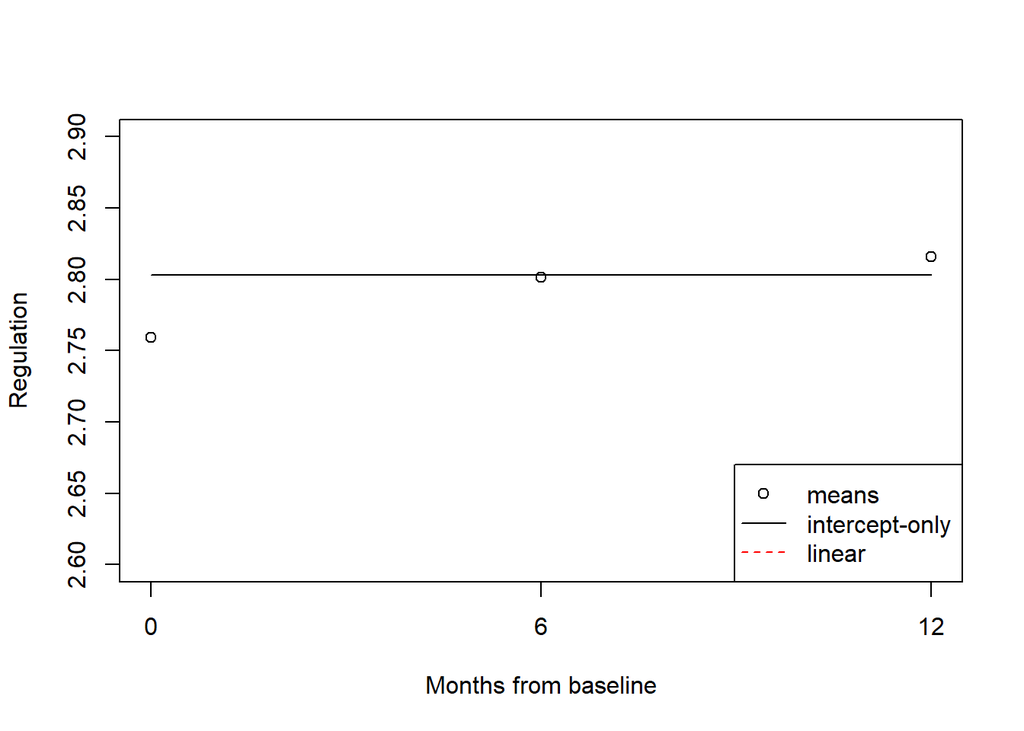

```r
# attach pathwayswide data
attach(pathwayswide)
# store factor loadings in a variable
x=0:2
# translate them into months
month=x*6
# store the variable means for plotting
means <- c(mean(walden_0,na.rm=T),
           mean(walden_1,na.rm=T),
           mean(walden_2,na.rm=T))
# calculate predictions from intercept-only and linear models
# coef() gets coefficients from the model, and then we're extracting the mean intercept and slope values to plug into prediction equations.
yint=x*0+coef(intFit)["I~1"]
ylin=x*coef(linFit)["S~1"]+coef(linFit)["I~1"]

# plot means and two average trajectories

plot(x=x,
     y=means,
     xaxt="n",
     ylab="Regulation",
     xlab="Months from baseline",
     ylim=c(2.6,2.9))
lines(x=x,y=yint)
lines(x=x,y=ylin,
      col="red",
      lty=2)
legend("bottomright",
       legend=c("means","intercept-only","linear"),
       lty=c(NA,1,2),
       pch=c(1,NA,NA),
       col=c("black","black","red"))
axis(1,at=x,labels=month)
```